# Freesurfer Output Analysis

Ryan Loke**, John L.K. Kramer

##### **Email**: lokeryan@student.ubc.ca

##### PhD Student

###### Department of Anesthesiology, Pharmacology and Therapeutics, University of British Columbia, Vancouver, Canada

###### International Collaborations on Repair Discoveries (ICORD), Vancouver, Canada

## Overview

Disclaimer: I am writing this tutorial from a Windows based computer, if you’re using a Macbook, things may look or function slightly different. To my knowledge, some packages and dependencies may differ, but the ones used here should be fine. **Please email me if you encounter any troubles!**

This document will run through the standardized analysis we will use for our spinal cord injury meta analysis. This analysis will take place after the MRI images have been processed using the Freesurfer reconall pipeline, and the statistics have been aggregated into their respective ‘.csv’ files using the provided scripts. Below is a rundown of the files you should have.

| File Name | Contents |
| --- | --- |
| cortical_stats_long.csv | Individual level structural cortical statistics in long format. |
| metadata.csv | The metadata for your study population |
| subcortical_volumes.csv | Individual level volumetric values for subcortical structures. |
| ICV_data.csv | Individual level intracranial volume (ICV) values |
| cortical_thickness.csv | Individual level, cortical thickness in the left and right hemisphere. |

The beginning of this document will assume the user has little to no experience in R/RStudio. If you are unfamiliar with the language/interface, Google and ChatGPT are both great debugging tools, however, feel free to reach out if any issue remains persistent. This should be easy for everyone to follow. If you know what you’re doing, please feel free to skip around to the important parts. Code can be copied to your clipboard using the dark red button on the top left of each code chunk.

## RStudio Overview

RStudio is a integrated development environment for the programming language R, a language for statistical computing and graphics. When first opening RStudio after downloading R, your setup will look something like this.

[figure not shown]

### Creating a new project

When starting a new analysis for a project, you **always** want to start a new project. First, hit ‘File’ -> ‘New Project…’ -> ‘New Directory’ -> ‘New Project’. You should see a window like this, and name your project whatever you’d like to, and select the location of where you want the folder to be created. Click ‘Create Project’.

[figure not shown]

### RStudio workspace

This is the default work space. The console will take the entirety of the left screen, you want to make it smaller by clicking the bar that says ‘Source’ along the top of the screen. Now you should have four windows.

The top left is where you should always write your script. You can run code in the console, but **it will not be saved**. By writing code in Source pane, you can save and edit your code for future analyses. It also makes it much easier to track what you have already done. Scripts can be saved by ‘Ctrl/Cmd’ + ‘s’. Code can be ran by clicking or highlighting the line(s) of code you want to run, then pressing **Ctrl/Cmd + Enter**.

The bottom left window is the console, which shows the output of code you run. You can run code here by typing it into the console, but it is difficult to keep track of what you’re running as code ran here is not saved. Please write and run all your code in the Source pane (top left).

The top right window is your environment. Any files imported, or any variables created will be listed here. The bottom right pane is a multifunctional pane. It displays files in your current working directory, and any graphics you choose to make.

[figure not shown]

## Installing packages

To start, we need to download and load some packages (dependencies) necessary to process and analyze the data. The code `install.packages("package_name")` installs the packages into your RStudio system. Installing packages only needs to be done **once** for every computer. Below are the packages used.

```r
install.packages("tidyverse")
install.packages("data.table")
install.packages("multcomp")
install.packages("effsize")
install.packages("writexl")
install.packages("ggpubr")
```

### Loading the libraries

```r
library(tidyverse)
library(data.table)
library(multcomp)
library(effsize)
library(writexl)
library(ggpubr)
```

## Importing your data

Next, we need to import the first .csv file for analysis. We will start with `cortical_stats_long.csv`. Hit ‘File’ -> ‘Import Dataset’ -> ‘From Text (Base)’.

That will bring up a new window, where you can browse for the file on your computer. Locate the .csv file which should be named `cortical_stats_long.csv`, and click open. Wait for RStudio to detect the data format. You may have to click “Yes” under the heading row. Check the Data Frame window on the bottom right and make sure it matches the picture below. Then hit ‘Import’.

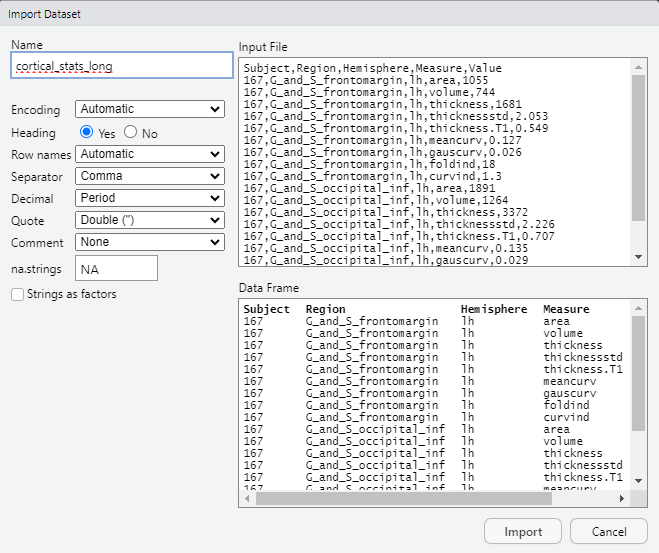

A new window will open up, displaying the entire imported data set. It will also appear in your environment on the top right panel of the screen.

### An alternative way to import data

You can also use the following line of code to import the data. You will need to **change the pathway** to fit your own system

```r
#If you use this method to import your data, make sure to change the file path to match your own machine.

cortical_stats_long <- read.csv(
  "R:/43_Ryan_Loke/Side Projects/Freesurfer_Analysis/cortical_stats_long.csv",
  sep =","
)

#This code allows you to see the first four columns of the dataframe.
head(cortical_stats_long)
```

```
##   Subject               Region Hemisphere      Measure    Value
## 1     167 G_and_S_frontomargin         lh         area 1055.000
## 2     167 G_and_S_frontomargin         lh       volume  744.000
## 3     167 G_and_S_frontomargin         lh    thickness 1681.000
## 4     167 G_and_S_frontomargin         lh thicknessstd    2.053
## 5     167 G_and_S_frontomargin         lh thickness.T1    0.549
## 6     167 G_and_S_frontomargin         lh     meancurv    0.127
```

## Setting up

First, we need to create a dataframe that duplicates the data. This is because we never want to edit the mastersheet, just in case we mess up, and so we don’t have to import the data again. SCI_Data is now our main data frame.

```r
SCI_Data <- data.frame(cortical_stats_long)
```

### Freesurfer output rundown

In case you were curious as to what some of these metrics mean, here is a quick summary of all of them, and why we are choosing to look at it.

[output not shown]

### Cohort labeling

This walk-through also assumes your data has three cohorts, you may have less, and thus may have to adjust what you analyze accordingly. These are the names I will use in my metadata labeling, you may use your own labels but please keep track of them!

| Group | Code | Comment |
| --- | --- | --- |
| Healthy controls | SCI_H | Individuals without SCI |
| SCI with neuropathic pain | SCI_P | Individuals with SCI and pain |
| SCI without neuropathic pain | SCI_nNP | Individuals with SCI, but no pain |
| SCI combined | SCI | All individuals with an SCI, (SCI_P + SCI_nNP) |

### Metadata labeling

Import your metadata .csv or .xlsx into RStudio using either previously described method. I have displayed the column names of my metadata sheet, yours may look different so you may have to change some of the code following.

```r
#If you are using this method to import your metadata csv/xlsx, please make sure to change the file pathway.

metadata_SCI <- read.csv(
  "R:/43_Ryan_Loke/Side Projects/VolBrain/SCI_Metadata_FS.csv",
  sep=","
)

metadata <- data.frame(metadata_SCI)

colnames(metadata)
```

```
## [1] "ID"   "code" "age"  "sex"
```

This will match your ID numbers from your `SCI_Data` dataframe to your metadata labeling. Code in this case refers to the cohort labeling for each individual subject. We also added sex and age to the `SCI_Data` dataframe, you may choose to add other variables to your sheet, or omit them if you don’t have them.

```r
SCI_Data <- SCI_Data %>%
  left_join(dplyr::select(metadata, ID, code, sex, age), by = c("Subject" = "ID"))

colnames(SCI_Data)
```

```
## [1] "Subject"    "Region"     "Hemisphere" "Measure"    "Value"
## [6] "code"       "sex"        "age"
```

### Transforming to wide format

Last step before processing is a transformation of the data frame from long to wide format. The naming scheme we will adopt for the region will go as `hemisphere_region_measure`. For example, the first region `lh_G_and_S_frontomargin_area`, refers to the left hemisphere, fronto-marginal gyrus (of Wernicke) and sulcus’ area.

[A full list of the parcellations analyzed can be found here with their complete names](https://pmc.ncbi.nlm.nih.gov/articles/PMC2937159/table/T1/)

```r
SCI_Data_wide <- SCI_Data %>%
  mutate(hemisphere_region_measure = paste(Hemisphere, Region, Measure, sep = "_")) %>%
  dplyr::select(-Region, -Hemisphere, -Measure) %>%
  pivot_wider(names_from = hemisphere_region_measure, values_from = Value)
```

The output in wide format should look something like this… (data is made up). Data frame should also contain contain ~1336 columns (74 regions * 2 hemispheres * 9 measurements + 4 identifying columns). You can check by using this line `ncol(SCI_Data_wide)` to check.

| Subject | code | sex | age | lh_G_and_S_frontomargin_area | lh_G_and_s_frontomargin_volume |
| --- | --- | --- | --- | --- | --- |
| 15 | SCI_P | Male | 24 | 1024 | 800 |
| 16 | SCI_P | Female | 32 | 980 | 834 |

## Analysis Preprocessing

This script goes over 4 main analyses. Below is a table that goes over the comparisons.

| Code | Comparison |
| --- | --- |
| PvH | Individuals with SCI and neuropathic pain, versus healthy individuals |
| nNPvH | Individuals with SCI but no neuropathic pain, versus healthy individuals |
| nNPvP | Individuals with SCI but no neuropathic pain, versus individuals with SCI and neuropathic pain |
| IvH | Individuals with SCI (both with neuropathic pain and without) versus healthy individuals |

### Subsetting dataframes for analysis

We will be generating 4 dataframes, using the schematic `SCI_code` where code will be one of the four codes referenced in the table above for their respective analysis. This will subset our master data frame `SCI_Data_wide` into four smaller datasheets containing only our subjects of interest.

```r
SCI_PvH <- data.frame(SCI_Data_wide[SCI_Data_wide$code %in% c("SCI_P","SCI_H"), ])

SCI_nNPvH <- data.frame(SCI_Data_wide[SCI_Data_wide$code %in% c("SCI_nNP","SCI_H"), ])

SCI_nNPvP <- data.frame(SCI_Data_wide[SCI_Data_wide$code %in% c("SCI_nNP","SCI_P"), ])

SCI_IvH <- as.data.frame(SCI_Data_wide %>%
  mutate(code = case_when(
    code %in% c("SCI_P", "SCI_nNP") ~"SCI",
    TRUE ~ code
  )))
```

Now we have 4 different data frames which will be used for our analyses.

## Analysis code skeleton

Below is a skeleton of the analysis loop that will be run for each of the 4 dataframes. You will need to change some variables in this skeleton in order for it to work, but they have been clearly marked by surrounding asterisks. Under the skeleton will be a table for what you need to replace the variable with. Included are also comments in the body of code showing exactly what each chunk is doing. Below this chunk of code, I have also fully written out all analyses.

```r
#We will be storing results into a dataframe called *results*.
#Please change this name for every analysis conducted.
#The '5' in the first line of code means analyses will start on column 5.
#Change this number if your data doesn't start on column 5.

*results* <- lapply(colnames(*dataframe*[5:ncol(*dataframe*)],
                                function(region) {

  #Conducting a t-test between groups (code), for each region.
  t_test <- t.test(*dataframe*[[region]] ~ *dataframe*$code)

  #Conducting an effect size analysis between groups for each region.
  d_result <- cohen.d(*dataframe*[[region]] ~ *dataframe*$code)
  d_value <- d_result$estimate

  #Finding the total number of individuals in each group.
  #Group refers to the code from the cohort labeling such as, SCI_H, SCI_P and SCI_nNP.
  #Please follow the example when labeling the groups. The letter before v is group 1.
  #e.g. SCI_PvH -> group 1 = SCI_P, group 2 = SCI_H.
  n1 <- sum(*dataframe*$code == "*group1*")
  n2 <- sum(*dataframe*$code == "*group2*")

  #Calculating standard error and confidence intervals of our effect size analysis.
  #Nothing needs to be changed in these three lines.
  se_d <- sqrt((n1 + n2) / (n1 * n2) + (d_value^2) / (2 * (n1 + n2)))
  ci_lower <- d_value - 1.96 * se_d
  ci_upper <- d_value + 1.96 * se_d

  #This is piecing all of the data together into one data frame.
  data.frame(
    Region = region,
    p_value = t_test$p.value,
    Mean_Group1 = mean(*dataframe*[*dataframe*$code == "*group1",
                                        region], na.rm = TRUE),
    Mean_Group2 = mean(*dataframe*[*dataframe*$code == "*group2*",
                                        region], na.rm = TRUE),
    t_statistic = t_test$statistic,
    Cohen_d = d_value,
    SE_Cohen_d = se_d,
    CI_lower = ci_lower,
    CI_upper = ci_upper
    )
})

#Combine all elements in the results to a dataframe called summary.
*summary* <- do.call(rbind, *results*)

#reorder the summary by decreasing p value, this step is not necessary.
*summary* <- *summary*[order(*summary*$p_value),]

#exports the results into an xlsx file to your working directory.
#please change code to match the analysis. e.g. PvH, nNPvH, etc.
write_xlsx(*summary*, "SCI_*code*_results.xlsx")
```

Here is a table of what you should change each variable to in the code skeleton.

| What it appears as in the skeleton | What you should change it to | example |
| --- | --- | --- |
| results | code_results, where code is the particular analysis you are conducting | PvH_results, nNPvH_results |
| dataframe | The generated dataframe for a particular analysis. | SCI_PvH, SCI_nNPvH |
| group1 | The first group before the versus | SCI_PvH, group1 = SCI_P |
| group2 | The second group after the versus | SCI_PvH, group2 = SCI_H |
| summary | code_summary, where code is the analysis you are conducting. | PvH_summary, nNPvH_summary |

### Analysis code written out

This chunk analyzes people with spinal cord injury and neuropathic pain to people without spinal cord injury.

```r
PvH_results <- lapply(colnames(SCI_PvH)[5:ncol(SCI_PvH)],
                                function(region) {

  t_test <- t.test(SCI_PvH[[region]] ~ SCI_PvH$code)

  d_result <- cohen.d(SCI_PvH[[region]] ~ SCI_PvH$code)
  d_value <- d_result$estimate

  n1 <- sum(SCI_PvH$code == "SCI_P")
  n2 <- sum(SCI_PvH$code == "SCI_H")

  se_d <- sqrt((n1 + n2) / (n1 * n2) + (d_value^2) / (2 * (n1 + n2)))
  ci_lower <- d_value - 1.96 * se_d
  ci_upper <- d_value + 1.96 * se_d

  data.frame(
    Region = region,
    p_value = t_test$p.value,
    Mean_Group1 = mean(SCI_PvH[SCI_PvH$code == "SCI_P",
                                        region], na.rm = TRUE),
    Mean_Group2 = mean(SCI_PvH[SCI_PvH$code == "SCI_H",
                                        region], na.rm = TRUE),
    t_statistic = t_test$statistic,
    Cohen_d = d_value,
    SE_Cohen_d = se_d,
    CI_lower = ci_lower,
    CI_upper = ci_upper
    )
})


PvH_summary <- do.call(rbind, PvH_results)

PvH_summary <- PvH_summary[order(PvH_summary$p_value),]

write_xlsx(PvH_summary, "SCI_PvH_results.xlsx")
```

This chunk analyzes individuals with spinal cord injury without neuropathic pain, to controls

```r
nNPvH_results <- lapply(colnames(SCI_nNPvH)[5:ncol(SCI_nNPvH)],
                                function(region) {

  t_test <- t.test(SCI_nNPvH[[region]] ~ SCI_nNPvH$code)

  d_result <- cohen.d(SCI_nNPvH[[region]] ~ SCI_nNPvH$code)
  d_value <- d_result$estimate

  n1 <- sum(SCI_nNPvH$code == "SCI_nNP")
  n2 <- sum(SCI_nNPvH$code == "SCI_H")

  se_d <- sqrt((n1 + n2) / (n1 * n2) + (d_value^2) / (2 * (n1 + n2)))
  ci_lower <- d_value - 1.96 * se_d
  ci_upper <- d_value + 1.96 * se_d

  data.frame(
    Region = region,
    p_value = t_test$p.value,
    Mean_Group1 = mean(SCI_nNPvH[SCI_nNPvH$code == "SCI_nNP",
                                        region], na.rm = TRUE),
    Mean_Group2 = mean(SCI_nNPvH[SCI_nNPvH$code == "SCI_H",
                                        region], na.rm = TRUE),
    t_statistic = t_test$statistic,
    Cohen_d = d_value,
    SE_Cohen_d = se_d,
    CI_lower = ci_lower,
    CI_upper = ci_upper
    )
})

nNPvH_summary <- do.call(rbind, nNPvH_results)

nNPvH_summary <- nNPvH_summary[order(nNPvH_summary$p_value),]

write_xlsx(nNPvH_summary, "SCI_nNPvH_results.xlsx")
```

This chunk compares individuals with spinal cord injury and neuropathic pain, to individuals with spinal cord injury but without neuropathic pain.

```r
nNPvP_results <- lapply(colnames(SCI_nNPvP)[5:ncol(SCI_nNPvP)],
                                function(region) {

  t_test <- t.test(SCI_nNPvP[[region]] ~ SCI_nNPvP$code)

  d_result <- cohen.d(SCI_nNPvP[[region]] ~ SCI_nNPvP$code)
  d_value <- d_result$estimate

  n1 <- sum(SCI_nNPvP$code == "SCI_nNP")
  n2 <- sum(SCI_nNPvP$code == "SCI_P")

  se_d <- sqrt((n1 + n2) / (n1 * n2) + (d_value^2) / (2 * (n1 + n2)))
  ci_lower <- d_value - 1.96 * se_d
  ci_upper <- d_value + 1.96 * se_d

  data.frame(
    Region = region,
    p_value = t_test$p.value,
    Mean_Group1 = mean(SCI_nNPvP[SCI_nNPvP$code == "SCI_nNP",
                                        region], na.rm = TRUE),
    Mean_Group2 = mean(SCI_nNPvP[SCI_nNPvP$code == "SCI_P",
                                        region], na.rm = TRUE),
    t_statistic = t_test$statistic,
    Cohen_d = d_value,
    SE_Cohen_d = se_d,
    CI_lower = ci_lower,
    CI_upper = ci_upper
    )
})

nNPvP_summary <- do.call(rbind, nNPvP_results)

nNPvP_summary <- nNPvP_summary[order(nNPvP_summary$p_value),]

write_xlsx(nNPvP_summary, "SCI_nNPvP_results.xlsx")
```

This last chunk compares all individuals with spinal cord injury (with and without neuropathic pain) to individuals without spinal cord injury.

```r
IvH_results <- lapply(colnames(SCI_IvH)[5:ncol(SCI_IvH)],
                                function(region) {

  t_test <- t.test(SCI_IvH[[region]] ~ SCI_IvH$code)

  d_result <- cohen.d(SCI_IvH[[region]] ~ SCI_IvH$code)
  d_value <- d_result$estimate

  n1 <- sum(SCI_IvH$code == "SCI")
  n2 <- sum(SCI_IvH$code == "SCI_H")

  se_d <- sqrt((n1 + n2) / (n1 * n2) + (d_value^2) / (2 * (n1 + n2)))
  ci_lower <- d_value - 1.96 * se_d
  ci_upper <- d_value + 1.96 * se_d

  data.frame(
    Region = region,
    p_value = t_test$p.value,
    Mean_Group1 = mean(SCI_IvH[SCI_IvH$code == "SCI",
                                        region], na.rm = TRUE),
    Mean_Group2 = mean(SCI_IvH[SCI_IvH$code == "SCI_H",
                                        region], na.rm = TRUE),
    t_statistic = t_test$statistic,
    Cohen_d = d_value,
    SE_Cohen_d = se_d,
    CI_lower = ci_lower,
    CI_upper = ci_upper
    )
})

IvH_summary <- do.call(rbind, IvH_results)

IvH_summary <- IvH_summary[order(IvH_summary$p_value),]

write_xlsx(IvH_summary, "SCI_IvH_results.xlsx")
```

## Subcortical Volumes Analysis

This analysis is going to be largely similar to the previous analysis, so I won’t be going as in depth into the preparation and details of the code, and will just write out the code with some comments. It follows pretty much the exact same process as the previous analysis. I’d be happy to answer any questions through email.

### Importing and Preprocessing

Import the data and get rid of any columns that only contain zeros (should just be a few).

```r
subcortical_volumes <- read.csv(
  "R:/43_Ryan_Loke/Side Projects/Freesurfer_Analysis/subcortical_volumes.csv",
  sep = '\t'
)

#Get rid of any columns that contain only zeros
subcortical_volumes <- subcortical_volumes[ ,colSums(subcortical_volumes != 0) > 0]
```

Add the metadata after the first column and change the column name of the first column.

```r
subcortical_volumes <- cbind(subcortical_volumes[ , 1, drop = F], metadata[c("code","sex","age")],
                             subcortical_volumes[, -1, drop = F])

colnames(subcortical_volumes)[1] <- "SubjectID"
```

We will be conducting the same four analyses for this dataset as well, so we will be subsetting the data the same way again. The naming scheme will remain the same (PvH, nNPvH, etc. for the comparisons), but the first three letters will change to SUB to indicate we are doing a subcortical analysis.

```r
SUB_PvH <- data.frame(subcortical_volumes[subcortical_volumes$code %in% c("SCI_P","SCI_H"), ])

SUB_nNPvH <- data.frame(subcortical_volumes[subcortical_volumes$code %in% c("SCI_nNP", "SCI_H"), ])

SUB_nNPvP <- data.frame(subcortical_volumes[subcortical_volumes$code %in% c("SCI_nNP", "SCI_P"), ])

SUB_IvH <- as.data.frame(subcortical_volumes %>%
  mutate(code = case_when(
   code %in% c("SCI_P", "SCI_nNP") ~"SCI",
   TRUE ~ code
 )))
```

### Analysis

This is the exact same skeleton code as before, just changing the dataframe being used. The naming scheme is the same, just adding SUB in front to indicated subcortical analysis. Here we are starting with individuals with spinal cord injury and neuropathic pain versus controls.

```r
SUB_PvH_results <- lapply(colnames(SUB_PvH)[5:ncol(SUB_PvH)],
                                function(region) {

  t_test <- t.test(SUB_PvH[[region]] ~ SUB_PvH$code)

  d_result <- cohen.d(SUB_PvH[[region]] ~ SUB_PvH$code)
  d_value <- d_result$estimate

  n1 <- sum(SUB_PvH$code == "SCI_P")
  n2 <- sum(SUB_PvH$code == "SCI_H")

  se_d <- sqrt((n1 + n2) / (n1 * n2) + (d_value^2) / (2 * (n1 + n2)))
  ci_lower <- d_value - 1.96 * se_d
  ci_upper <- d_value + 1.96 * se_d

  data.frame(
    Region = region,
    p_value = t_test$p.value,
    Mean_Group1 = mean(SUB_PvH[SUB_PvH$code == "SCI_P",
                                        region], na.rm = TRUE),
    Mean_Group2 = mean(SUB_PvH[SUB_PvH$code == "SCI_H",
                                        region], na.rm = TRUE),
    t_statistic = t_test$statistic,
    Cohen_d = d_value,
    SE_Cohen_d = se_d,
    CI_lower = ci_lower,
    CI_upper = ci_upper
    )
})


SUB_PvH_summary <- do.call(rbind, SUB_PvH_results)

SUB_PvH_summary <- SUB_PvH_summary[order(SUB_PvH_summary$p_value),]

write_xlsx(SUB_PvH_summary, "SUB_PvH_results.xlsx")
```

This chunk analyzes individuals with spinal cord injury without neuropathic pain, to controls.

```r
SUB_nNPvH_results <- lapply(colnames(SUB_nNPvH)[5:ncol(SUB_nNPvH)],
                                function(region) {

  t_test <- t.test(SUB_nNPvH[[region]] ~ SUB_nNPvH$code)

  d_result <- cohen.d(SUB_nNPvH[[region]] ~ SUB_nNPvH$code)
  d_value <- d_result$estimate

  n1 <- sum(SUB_nNPvH$code == "SCI_nNP")
  n2 <- sum(SUB_nNPvH$code == "SCI_H")

  se_d <- sqrt((n1 + n2) / (n1 * n2) + (d_value^2) / (2 * (n1 + n2)))
  ci_lower <- d_value - 1.96 * se_d
  ci_upper <- d_value + 1.96 * se_d

  data.frame(
    Region = region,
    p_value = t_test$p.value,
    Mean_Group1 = mean(SUB_nNPvH[SUB_nNPvH$code == "SCI_nNP",
                                        region], na.rm = TRUE),
    Mean_Group2 = mean(SUB_nNPvH[SUB_nNPvH$code == "SCI_H",
                                        region], na.rm = TRUE),
    t_statistic = t_test$statistic,
    Cohen_d = d_value,
    SE_Cohen_d = se_d,
    CI_lower = ci_lower,
    CI_upper = ci_upper
    )
})

SUB_nNPvH_summary <- do.call(rbind, SUB_nNPvH_results)

SUB_nNPvH_summary <- SUB_nNPvH_summary[order(SUB_nNPvH_summary$p_value),]

write_xlsx(SUB_nNPvH_summary, "SUB_nNPvH_results.xlsx")
```

This comparison is for individuals with spinal cord injury, without neuropathic pain versus individuals with spinal cord injury with neuropathic pain.

```r
SUB_nNPvP_results <- lapply(colnames(SUB_nNPvP)[5:ncol(SUB_nNPvP)],
                                function(region) {

  t_test <- t.test(SUB_nNPvP[[region]] ~ SUB_nNPvP$code)

  d_result <- cohen.d(SUB_nNPvP[[region]] ~ SUB_nNPvP$code)
  d_value <- d_result$estimate

  n1 <- sum(SUB_nNPvP$code == "SCI_nNP")
  n2 <- sum(SUB_nNPvP$code == "SCI_P")

  se_d <- sqrt((n1 + n2) / (n1 * n2) + (d_value^2) / (2 * (n1 + n2)))
  ci_lower <- d_value - 1.96 * se_d
  ci_upper <- d_value + 1.96 * se_d

  data.frame(
    Region = region,
    p_value = t_test$p.value,
    Mean_Group1 = mean(SUB_nNPvP[SUB_nNPvP$code == "SCI_nNP",
                                        region], na.rm = TRUE),
    Mean_Group2 = mean(SUB_nNPvP[SUB_nNPvP$code == "SCI_P",
                                        region], na.rm = TRUE),
    t_statistic = t_test$statistic,
    Cohen_d = d_value,
    SE_Cohen_d = se_d,
    CI_lower = ci_lower,
    CI_upper = ci_upper
    )
})

SUB_nNPvP_summary <- do.call(rbind, SUB_nNPvP_results)

SUB_nNPvP_summary <- SUB_nNPvP_summary[order(SUB_nNPvP_summary$p_value),]

write_xlsx(SUB_nNPvP_summary, "SUB_nNPvP_results.xlsx")
```

Lastly, here we are comparing all individuals with spinal cord injury to controls.

```r
SUB_IvH_results <- lapply(colnames(SUB_IvH)[5:ncol(SUB_IvH)],
                                function(region) {

  t_test <- t.test(SUB_IvH[[region]] ~ SUB_IvH$code)

  d_result <- cohen.d(SUB_IvH[[region]] ~ SUB_IvH$code)
  d_value <- d_result$estimate

  n1 <- sum(SUB_IvH$code == "SCI")
  n2 <- sum(SUB_IvH$code == "SCI_H")

  se_d <- sqrt((n1 + n2) / (n1 * n2) + (d_value^2) / (2 * (n1 + n2)))
  ci_lower <- d_value - 1.96 * se_d
  ci_upper <- d_value + 1.96 * se_d

  data.frame(
    Region = region,
    p_value = t_test$p.value,
    Mean_Group1 = mean(SUB_IvH[SUB_IvH$code == "SCI",
                                        region], na.rm = TRUE),
    Mean_Group2 = mean(SUB_IvH[SUB_IvH$code == "SCI_H",
                                        region], na.rm = TRUE),
    t_statistic = t_test$statistic,
    Cohen_d = d_value,
    SE_Cohen_d = se_d,
    CI_lower = ci_lower,
    CI_upper = ci_upper
    )
})

SUB_IvH_summary <- do.call(rbind, SUB_IvH_results)

SUB_IvH_summary <- SUB_IvH_summary[order(SUB_IvH_summary$p_value),]

write_xlsx(SUB_IvH_summary, "SUB_IvH_results.xlsx")
```

## Quick ICV Summary

For this analysis, we are just going to examine ICV differences between groups. This section will be much quicker. Since I have gone over most of the functions beforehand, I will just include the entire code below with some comments. We are not conducting any comparative analyses here, just summarizing group ICV values, along with their standard deviation, and exporting those statistics into a .xslx file.

```r
#Import the data. You will have to change the path to your own file.

ICV_data <- read.csv(
  "R:/43_Ryan_Loke/Side Projects/Freesurfer_Analysis/ICV_data.csv",
  sep = ","
)

#This gets rid of any columns of NA that may have been created.
ICV_data <- ICV_data[, colSums(is.na(ICV_data)) < nrow(ICV_data)]

#Adding metadata
ICV_data <- cbind(ICV_data, metadata[c("code","sex","age")])

#Group level summary statistics for age and standard deviation
ICV_Summary <- ICV_data %>%
  group_by(code, sex) %>%
  summarize(
    mean_ICV = mean(ICV, na.rm = T),
    sd_ICV = sd(ICV, na.rm = T),
    n = n()
  )

#export summary statistics.
write_xlsx(ICV_Summary, "ICV_Summary.xlsx")
```

## Quick Cortical Thickness Summary

Last quick summary analysis, this one looks to aggergate cortical thickness data and export the data into a .xlsx file. This is the exact same as the previous code chunk, but with a few extra lines to compensate for left and right hemisphere.

```r
#Import the data. You will have to change the path to your own file.

CT_data <- read.csv(
  "R:/43_Ryan_Loke/Side Projects/Freesurfer_Analysis/cortical_thickness_test.csv",
  sep = ","
)

#Adding metadata
CT_data <- cbind(CT_data, metadata[c("code","sex","age")])

#Group level summary statistics for age and standard deviation
CT_Summary <- CT_data %>%
  group_by(code, sex) %>%
  summarize(
    mean_rh_CT = mean(rh_thickness, na.rm = T),
    mean_lh_CT = mean(lh_thickness, na.rm = T),
    sd_rh_CT = sd(rh_thickness, na.rm = T),
    sd_lh_CT = sd(lh_thickness, na.rm = T),
    n = n()
  )

#export summary statistics.
write_xlsx(CT_Summary, "CT_Summary.xlsx")
```